# Functional programming

Jae Yeon Kim

04 February, 2022

# 1 Setup

```r
# Install packages
if (!require("pacman")) {
  install.packages("pacman")
}
```

```r
pacman::p_load(
  tidyverse, # tidyverse pkgs including purrr
  bench, # performance test
  tictoc, # performance test
  broom, # tidy modeling
  glue, # paste string and objects
  furrr, # parallel processing
  rvest, # web scraping
  devtools, # dev tools
  usethis, # workflow
  roxygen2, # documentation
  testthat, # testing
  patchwork) # arranging ggplots
```

# 2 Automating repeated things

## 2.1 The Big Picture

> Anything that can be automated should be automated. Do as little as possible by hand. Do as much as possible with functions. - Hadley Wickham

The `purrr` package provides easy-to-use tools to automate repeated things in your entire R workflow (e.g., wrangling, modeling, and visualization). The result is cleaner, faster, more readable, and extendable code.

[figure not shown]

## 2.2 Objectives

1. How to use control flow in R using `if_`, `for loop`, and `apply`
2. How to use `map()` to automate workflow in a cleaner, faster, and more extendable way

## 2.3 Flow control

- Control structures = putting logic in code to control flow (e.g., `if`, `else`, `for`, `while`, `repeat`, `break`, `next`)
- Almost all the conditional operators used in Python also work in R. The basic loop setup is also very similar, with some small syntax adjustments.
- `if()` is a function whose arguments must be specified inside parentheses.
- `else`, however, is a reserved operator that takes no arguments. Note that there is no `elif` option — one simply writes `else if()`.
- Whereas operations to be executed after conditional evaluations in Python come after a `:`, R operations must only be enclosed in curly brackets: `{}`. Furthermore, there is no requirement for indentation.

### 2.3.1 if (one condition)

```r
x <- 5

if (x < 0) { # Condition
  print("x is negative") # Do something
}
```

```r
x <- -5

if (x < 0) {
  print("x is negative")
}
```

```
## [1] "x is negative"
```

### 2.3.2 if + else (two conditions)

```r
x <- 5

if (x < 0) {
  print("x is negative")
} else{
  print("x is positive")
}
```

```
## [1] "x is positive"
```

### 2.3.3 if + else if + else (three conditions)

```r
x <- 0

if (x < 0) { # Condition
  print("x is negative") # Do something

  } else if (x == 0) {

    print("x is zero") # Do something else

    } else {print("x is positive") # Do something else

      }
```

```
## [1] "x is zero"
```

- In general, it’s not a good idea to write nested code (lots of `else_if()` or `ifelse()`). It is not easy to read, debug, modulize, and extend.
- Instead, write functions and, if necessary, use `if()` only. We’ll come back to this later.

### 2.3.4 Functions

While functions are defined in Python using the `def` reserved operator, R sees functions as just another type of named object. Thus, they require explicit assignment to an object. This is done using the function `function()`, which creates a function taking the arguments specified in parentheses.

function = input + computation (begin -> end) + output

```r
simple.function <- function(x){
  print(x + 1)
}

simple.function(x = 2)
```

```
## [1] 3
```

```r
less.simple.function <- function(x, y){
  print(x - y + 1)
}

less.simple.function(x = 2, y = 10)
```

```
## [1] -7
```

Concerning returning function output, most of the same rules apply to Python. Be sure to remember that `return()` will only process a single object, so multiple items must usually be returned as a list. Note that your ordering of the functions matters, too.

```r
dumbfun <- function(x){
  return(x)
  print("This will never print :(")
}

dumbfun(x = "something")
```

```
## [1] "something"
```

```r
dumbfun <- function(x){
  print("Why did I print?")
  return(x)
}

dumbfun(x = "something")
```

```
## [1] "Why did I print?"
```

```
## [1] "something"
```

```r
dumbfun <- function(x,y){
  thing1 <- x
  thing2 <- y
  return(list(thing1, thing2))
}

dumbfun(x = "some text", y = "some data")
```

```
## [[1]]
## [1] "some text"
##
## [[2]]
## [1] "some data"
```

```r
dumbfun(x = c(5,10,15), y = "some data")
```

```
## [[1]]
## [1]  5 10 15
##
## [[2]]
## [1] "some data"
```

R functions also allow you to set default argument values:

```r
less.simple.function <- function(x, y = 0){
  print(x - y + 1)
}

less.simple.function(x = 2)
```

```
## [1] 3
```

```r
less.simple.function(x = 2, y = 10)
```

```
## [1] -7
```

Concerning specifying arguments, one can either use argument **position** specifications (i.e., the order) or argument **name** specifications. The latter is strongly preferred, as it is straightforward to specify incorrect argument values accidentally.

```r
send <- function(message, recipient, cc=NULL, bcc=NULL){
  print(paste(message, recipient, sep = ", "))
  print(paste("CC:", cc, sep = " "))
  print(paste("BCC:", bcc, sep = " "))
}

send(message = "Hello", recipient = "World", cc = "Sun", bcc = "Jane")
```

```
## [1] "Hello, World"
## [1] "CC: Sun"
## [1] "BCC: Jane"
```

```r
send("Hello", "World", "Sun", "Jane")
```

```
## [1] "Hello, World"
## [1] "CC: Sun"
## [1] "BCC: Jane"
```

```r
send("Hello", "Sun", "Jane", "World")
```

```
## [1] "Hello, Sun"
## [1] "CC: Jane"
## [1] "BCC: World"
```

```r
send(message = "Hello", cc = "Sun", bcc = c("Jane", "Rochelle"), recipient = "World")
```

```
## [1] "Hello, World"
## [1] "CC: Sun"
## [1] "BCC: Jane"     "BCC: Rochelle"
```

Also, note that functions don’t have what CS people called side-effects. Functions only define local variables = They don’t change objects stored in the global environment. (Consider the difference between `<-` and `=` for assignments.) That’s why you can use functions for reusable tasks since it does not interrupt other essential things in your system.

See [the following example](https://darrenjw.wordpress.com/2011/11/23/lexical-scope-and-function-closures-in-r/) from Wilkinson.

```r
a = 1
b = 2

f <- function(x)
{
  a*x + b
}

f(2)
```

```
## [1] 4
```

```r
g <- function(x)
{
  a = 2
  b = 1
  f(x)
}

g(2) # a equals still 1
```

```
## [1] 4
```

**Additional tips**

- Nonstandard evaluation

Nonstandard evaluation is an advanced subject. If you feel overwhelmed, you are more than welcome to skip this. But if you are serious about R programming, this is something you want to check out. For a deeper understanding of this issue, I recommend reading [Ren Kun’s very informative blog post](https://renkun.me/2014/12/03/tips-on-non-standard-evaluation-in-r/) carefully.

This part draws on one of the [the dplyr package articles](https://dplyr.tidyverse.org/articles/programming.html.

In tidyverse, calling a variable with or without quotation mark (string or not) makes little difference because tidyeval is a non-standard evaluation.

```r
# Using `mpg` instead of `mtcars$mpg` is called data masking.

mtcars %>% select(mpg)

mtcars %>% select("mpg")
```

Data and env-variables

```r
# df = environment variable
df <- data.frame(
  x = c(1:5),
  y = c(6:10)
  )

# x, y = data variables
df$x
```

```
## [1] 1 2 3 4 5
```

```r
df$y
```

```
## [1]  6  7  8  9 10
```

- Problem

```r
x <- NULL

var_summary <- function(env_var, data_var){

   env_var %>%
    summarise(mean = mean(data_var))

}
```

It’s because the mean() function doesn’t take `df$x` for data_var but `x.` So it would be best if you linked x with the environment variable.

```r
var_summary(df, x)
```

| mean |
| --- |
| NA |

This is how you can fix this.

```r
# Solution
vs_fix <- function(env_var, data_var){

   env_var %>%
    summarise(mean = mean({{data_var}}))

}

# You can also do this.
vs_fix_enhanced <- function(env_var, data_var){

   env_var %>%
    summarise("mean_{{data_var}}" := mean({{data_var}})) # If you use the glue package, this syntax is very intuitive.

}

vs_fix_enhanced(df, x)
```

| mean_x |
| --- |
| 3 |

If you have a character vector input …

```r
mtcars_count <- mtcars %>%
  names() %>%
  purrr::map(~count(mtcars, .data[[.x]])) # We're going to learn about map in the rest of this session.

mtcars_count[[1]]
```

| mpg | n |
| --- | --- |
| 10.4 | 2 |
| 13.3 | 1 |
| 14.3 | 1 |
| 14.7 | 1 |
| 15.0 | 1 |
| 15.2 | 2 |
| 15.5 | 1 |
| 15.8 | 1 |
| 16.4 | 1 |
| 17.3 | 1 |

[output cut: 15 more lines]

### 2.3.5 for loop

[figure not shown]

Concept map for a for loop. Source: https://teachtogether.tech/en/index.html#s:memory-concept-maps

Loops in R also work the same way as in Python, with just a few adjustments. First, recall that index positions in R start at 1. Second, `while()` and `for()` are functions rather than reserved operators, meaning they must take arguments in parentheses. Third, just like `else`, the `in` operator *is* reserved and takes no arguments in parentheses. Fourth, the conditional execution must appear between curly brackets. Finally, indentation is meaningless, but each new operation must appear on a new line.

- `while()`: when we have no idea how many times loop needs to be executed.
- `for()`: when we know how many times loop needs to be executed. This is likely to be the loop you will use most frequently.

```r
fruits <- c("apples", "oranges", "pears", "bananas")

# a while loop
i <- 1
while (i <= length(fruits)) {
  print(fruits[i])
  i <- i + 1
}
```

```
## [1] "apples"
## [1] "oranges"
## [1] "pears"
## [1] "bananas"
```

```r
# a for loop
for (i in 1:length(fruits)) {
  print(fruits[i])
}
```

```
## [1] "apples"
## [1] "oranges"
## [1] "pears"
## [1] "bananas"
```

### 2.3.6 apply family

While and for loops in R can be very slow. For this reason, R has many built-in iteration methods to speed up execution times. In many cases, packages will have “behind-the-scenes” ways to avoid `for loops`, but what if you need to write your function?

A common method of getting around for loops is the **apply** family of functions. These take a data structure and a function and apply a function over all the object elements.

```r
fruit <- c("apple", "orange", "pear", "banana")

# make function that takes in only one element
make.plural <- function(x){
   plural <- paste(x, 's', sep = '') # sep is for collapse, so collpase ''
   return(plural)
}

make.plural('apple')
```

```
## [1] "apples"
```

- `apply()` : loop over the margins (1 = row, 2 = column) of an array
- `lapply()` : loop over a list then returns a list
- `sapply()` : loop over a list then returns a named vector
- `tapply()`: loop over subsets of a vector
- `mapply()`: multivariate version of `lapply()`. Use this if you have a function that takes in 2 or more arguments.

```r
# apply that function to every element
lapply(fruit, make.plural) # returns a list
```

```
## [[1]]
## [1] "apples"
##
## [[2]]
## [1] "oranges"
##
## [[3]]
## [1] "pears"
##
## [[4]]
## [1] "bananas"
```

```r
sapply(fruit, make.plural) # returns a named vector
```

```
##     apple    orange      pear    banana
##  "apples" "oranges"   "pears" "bananas"
```

```r
library(purrr) # load package
map(fruit, make.plural) # type consistent
```

```
## [[1]]
## [1] "apples"
##
## [[2]]
## [1] "oranges"
##
## [[3]]
## [1] "pears"
##
## [[4]]
## [1] "bananas"
```

```r
# Why sapply is bad

sapply(1:100, paste) # return character
```

```
##   [1] "1"   "2"   "3"   "4"   "5"   "6"   "7"   "8"   "9"   "10"  "11"  "12"
##  [13] "13"  "14"  "15"  "16"  "17"  "18"  "19"  "20"  "21"  "22"  "23"  "24"
##  [25] "25"  "26"  "27"  "28"  "29"  "30"  "31"  "32"  "33"  "34"  "35"  "36"
##  [37] "37"  "38"  "39"  "40"  "41"  "42"  "43"  "44"  "45"  "46"  "47"  "48"
##  [49] "49"  "50"  "51"  "52"  "53"  "54"  "55"  "56"  "57"  "58"  "59"  "60"
##  [61] "61"  "62"  "63"  "64"  "65"  "66"  "67"  "68"  "69"  "70"  "71"  "72"
##  [73] "73"  "74"  "75"  "76"  "77"  "78"  "79"  "80"  "81"  "82"  "83"  "84"
##  [85] "85"  "86"  "87"  "88"  "89"  "90"  "91"  "92"  "93"  "94"  "95"  "96"
##  [97] "97"  "98"  "99"  "100"
```

```r
sapply(integer(), paste) # return list!
```

```
## list()
```

```r
library(purrr)
map(1:100, paste) # return list
```

```
## [[1]]
## [1] "1"
##
## [[2]]
## [1] "2"
##
## [[3]]
## [1] "3"
##
## [[4]]
## [1] "4"
##
## [[5]]
## [1] "5"
##
## [[6]]
## [1] "6"
##
## [[7]]
## [1] "7"
##
## [[8]]
## [1] "8"
##
## [[9]]
## [1] "9"
##
## [[10]]
## [1] "10"
##
## [[11]]
## [1] "11"
##
## [[12]]
## [1] "12"
##
## [[13]]
## [1] "13"
##
## [[14]]
```

[output cut: 244 more lines]

```
##
## [[96]]
## [1] "96"
##
## [[97]]
## [1] "97"
##
## [[98]]
## [1] "98"
##
## [[99]]
## [1] "99"
##
## [[100]]
## [1] "100"
```

```r
map(integer(), paste) # return list
```

```
## list()
```

## 2.4 purrr

### 2.4.1 Why map?

#### 2.4.1.1 Objectives

- How to use `purrr` to automate workflow in a cleaner, faster, and more extendable way

#### 2.4.1.2 Copy-and-paste programming

> Copy-and-paste programming, sometimes referred to as just pasting, is the production of highly repetitive computer programming code, as produced by copy and paste operations. It is primarily a pejorative term; those who use the term are often implying a lack of programming competence. It may also be the result of technology limitations (e.g., an insufficiently expressive development environment) as subroutines or libraries would normally be used instead. However, there are occasions when copy-and-paste programming is considered acceptable or necessary, such as for boilerplate, loop unrolling (when not supported automatically by the compiler), or certain programming idioms, and it is supported by some source code editors in the form of snippets. - Wikipedia
- The following exercise was inspired by [Wickham’s example](http://adv-r.had.co.nz/Functional-programming.html).
- Let’s imagine `df` is a survey dataset.
  - `a, b, c, d` = Survey questions
  - `-99`: non-responses
  - Your goal: replace `-99` with `NA`

```r
# Data

set.seed(1234) # for reproducibility

df <- tibble(
  "a" = sample(c(-99, 1:3), size = 5, replace = TRUE),
  "b" = sample(c(-99, 1:3), size = 5, replace = TRUE),
  "c" = sample(c(-99, 1:3), size = 5, replace = TRUE),
  "d" = sample(c(-99, 1:3), size = 5, replace = TRUE)
)
```

```r
# Copy and paste
df$a[df$a == -99] <- NA
df$b[df$b == -99] <- NA
df$c[df$c == -99] <- NA
df$d[df$d == -99] <- NA

df
```

| a | b | c | d |
| --- | --- | --- | --- |
| 3 | 3 | 3 | 1 |
| 3 | 2 | 3 | 1 |
| 1 | NA | 1 | 2 |
| 1 | NA | 2 | 1 |
| NA | 1 | 1 | 3 |

- **Challenge**. Explain why this solution is not very efficient (Hint: If `df$a[df$a == -99] <- NA` has an error, how will you fix it? A solution is not scalable if it’s not automatable.

#### 2.4.1.3 Using a function

- Let’s recall what’s function in R: `input + computation + output`
- If you write a function, you gain efficiency because you don’t need to copy and paste the computation part.

` function(input){

computation

return(output) } `

```r
# Function

fix_missing <- function(x) {
  x[x == -99] <- NA
  x
}

# Apply function to each column (vector)

df$a <- fix_missing(df$a)
df$b <- fix_missing(df$b)
df$c <- fix_missing(df$c)
df$d <- fix_missing(df$d)

df
```

| a | b | c | d |
| --- | --- | --- | --- |
| 3 | 3 | 3 | 1 |
| 3 | 2 | 3 | 1 |
| 1 | NA | 1 | 2 |
| 1 | NA | 2 | 1 |
| NA | 1 | 1 | 3 |

- **Challenge** Why is using function more efficient than 100% copying and pasting? Can you think about a way we can automate the process?
- Many options for automation in R: `for loop`, `apply` family, etc.
- Here’s a tidy solution that comes from the `purrr` package.
- The power and joy of one-liner.

```r
df <- purrr::map_df(df, fix_missing)

df
```

| a | b | c | d |
| --- | --- | --- | --- |
| 3 | 3 | 3 | 1 |
| 3 | 2 | 3 | 1 |
| 1 | NA | 1 | 2 |
| 1 | NA | 2 | 1 |
| NA | 1 | 1 | 3 |

`map()` is a higher-order function that applies a given function to each element of a list/vector.

```
- Input: Takes a vector/list.

- Computation: Calls the function once for each element of the vector

- Output: Returns in a list or whatever data format you prefer (e.g., `_df helper: dataframe`)
```

- **Challenge** If you run the code below, what will be the data type of the output?

```r
map(df, fix_missing)
```

```
## $a
## [1]  3  3  1  1 NA
##
## $b
## [1]  3  2 NA NA  1
##
## $c
## [1] 3 3 1 2 1
##
## $d
## [1] 1 1 2 1 3
```

- Why `map()` is a good alternative to `for loop`.

[video not shown]

The Joy of Functional Programming (for Data Science) - Hadley Wickham

```r
# Built-in data
data("airquality")

tic()

# Placeholder
out1 <- vector("double", ncol(airquality))

# Sequence variable
for (i in seq_along(airquality)) {

  # Assign an iteration result to each element of the placeholder list
  out1[[i]] <- mean(airquality[[i]], na.rm = TRUE)
}

toc()
```

```
## 0.007 sec elapsed
```

`map` is faster because it applies function to the items on the list/vector in parallel. Also, using `map_dbl` reduces an extra step you need to take. Hint: `map_dbl(x, mean, na.rm = TRUE)` = `vapply(x, mean, na.rm = TRUE, FUN.VALUE = double(1))`

```r
tic()
out1 <- airquality %>% map_dbl(mean, na.rm = TRUE)
toc()
```

```
## 0.002 sec elapsed
```

- In short, `map()` is more readable, faster, and easily extendable with other data science tasks (e.g., wrangling, modeling, and visualization) using `%>%`.
- Final point: Why not base R `apply` family?
- Short answer: `purrr::map()` is simpler to write.

**Additional tips**

Performance testing (profiling) is an important part of programming. `tictoc()` measures the time needed to run a target function for once. If you want a more robust measure of timing as well as information on memory (**speed** and **space** both matter for performance testing), consider using the [`bench` package](https://github.com/r-lib/bench) that is designed for high precision timing of R expressions.

```r
map_mark <- bench::mark(

  out1 <- airquality %>% map_dbl(mean, na.rm = TRUE)

  )

map_mark
```

```
## # A tibble: 1 × 6
##   expression                                              min   median `itr/sec`
##   <bch:expr>                                         <bch:tm> <bch:tm>     <dbl>
## 1 out1 <- airquality %>% map_dbl(mean, na.rm = TRUE)   66.7µs   75.1µs    12611.
## # … with 2 more variables: mem_alloc <bch:byt>, `gc/sec` <dbl>
```

#### 2.4.1.4 Applications

1. Many models
- One popular application of `map()` is to run regression models (or whatever model you want to run) on list-columns. No more copying and pasting for running many regression models on subgroups!

```r
# Have you ever tried this?
lm_A <- lm(y ~ x, subset(data, subgroup == "group_A"))
lm_B <- lm(y ~ x, subset(data, subgroup == "group_B"))
lm_C <- lm(y ~ x, subset(data, subgroup == "group_C"))
lm_D <- lm(y ~ x, subset(data, subgroup == "group_D"))
lm_E <- lm(y ~ x, subset(data, subgroup == "group_E"))
```

- For more information on this technique, read the Many Models subchapter of the [R for Data Science](https://r4ds.had.co.nz/many-models.html#creating-list-columns).

```r
# Function
lm_model <- function(df) {
  lm(Temp ~ Ozone, data = df)
}

# Map
models <- airquality %>%
  group_by(Month) %>%
  nest() %>% # Create list-columns
  mutate(ols = map(data, lm_model)) # Map
models$ols[1]
```

```
## [[1]]
##
## Call:
## lm(formula = Temp ~ Ozone, data = df)
##
## Coefficients:
## (Intercept)        Ozone
##     62.8842       0.1629
```

```r
# Add tidying
tidy_lm_model <- purrr::compose( # compose multiple functions
  broom::tidy, # convert lm objects into tidy tibbles
  lm_model
)

tidied_models <- airquality %>%
  group_by(Month) %>%
  nest() %>% # Create list-columns
  mutate(ols = map(data, tidy_lm_model))

tidied_models$ols[1]
```

```
## [[1]]
## # A tibble: 2 × 5
##   term        estimate std.error statistic  p.value
##   <chr>          <dbl>     <dbl>     <dbl>    <dbl>
## 1 (Intercept)   62.9      1.61       39.2  2.88e-23
## 2 Ozone          0.163    0.0500      3.26 3.31e- 3
```

2. Simulations

A good friend of `map()` function is `rerun()` function. This combination is really useful for simulations. Consider the following example.

- Base R approach

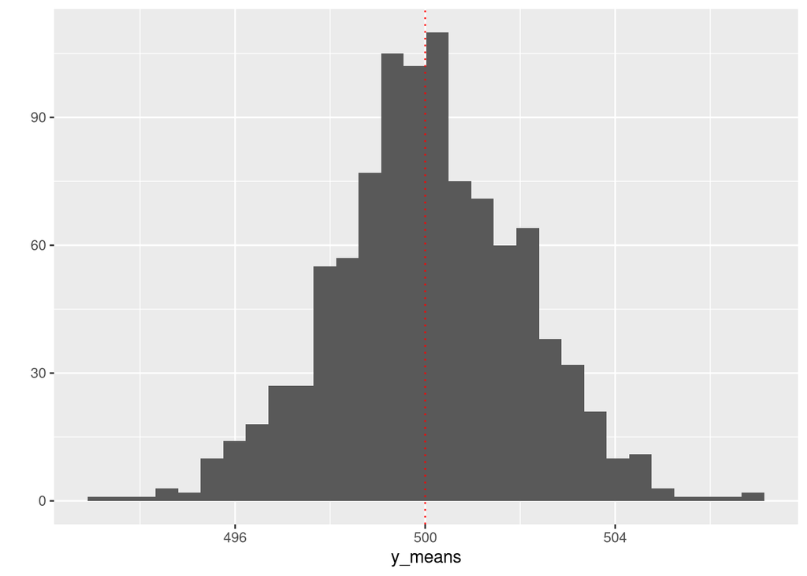

```r
set.seed(1234)

small_n <- 100 ; k <- 1000 ; mu <- 500 ; sigma <- 20

y_list <- rep(list(NA), k)

for (i in seq(k)) {

    y_list[[i]] <- rnorm(small_n, mu, sigma)

}

y_means <- unlist(lapply(y_list, mean))

qplot(y_means) +
   geom_vline(xintercept = 500, linetype = "dotted", color = "red")
```

- rerun() + map()

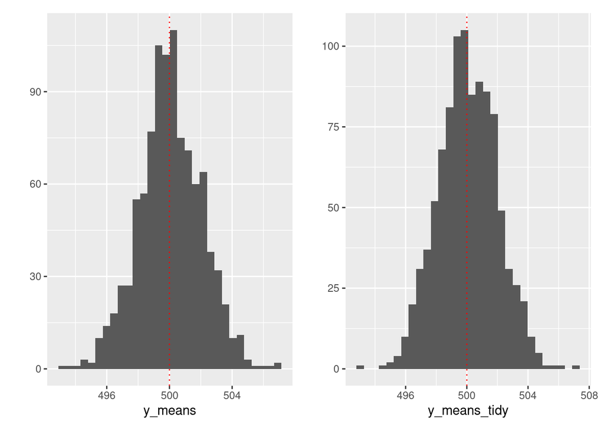

```r
small_n <- 100 ; k <- 1000; mu <- 500 ; sigma <- 20

y_tidy <- rerun(k, rnorm(small_n, mu, sigma))

y_means_tidy <- map_dbl(y_tidy, mean)

# Visualize
(qplot(y_means) +
   geom_vline(xintercept = 500, linetype = "dotted", color = "red")) +
(qplot(y_means_tidy) +
   geom_vline(xintercept = 500, linetype = "dotted", color = "red"))
```